# Proof of concept: ZDT4.mod

# Suggested ranges for performance

For this investigation, the concern is in determining the optimal conditions for selecting the correct quinone, so the concentration of NaOH is not particularly relevant. Suggestions will still be made, but it will be assessed last (conveniently, it is the least important variable in the importance ranking).

The ranges are determined sequentially in order of most important variable to least important. For the most important variable, the most viable condition is the range that gives it a probability of meeting the acceptance criteria that is halfway between the maximum and minimum (weak range suggestion) and 75% of the way up from the minimum (strong range suggestion). The next most important will have its marginal re-assessed by assuming that the previous most important variables fall within the optimal region.

The marginal for the pKa1 will be re-calculated with finer resolution.

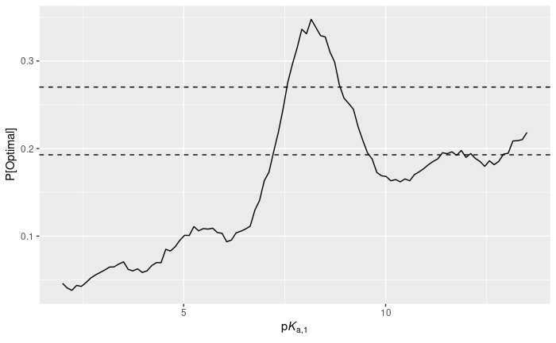

```r
# Plot the range to determine how to describe the optimal range
ggplot(range.pka1) +
  geom_path(mapping = aes(x = pka1, p.pka1)) +
  geom_hline(yintercept = 0.5*diff(range(range.pka1$p.pka1))+min(range.pka1$p.pka1), linetype = 2) +
  geom_hline(yintercept = 0.75*diff(range(range.pka1$p.pka1))+min(range.pka1$p.pka1), linetype = 2) +
  labs(x = expression('p'*italic(K)['a,1']), y = 'P[Optimal]')

# Weak range: between 7~10 and above 12. However, the tailing effect of being above 12 is barely over the cutoff, so will be omitted for simplicity.
print('First pKa:')
```

```
[1] "First pKa:"
```

```r
print('Weak range:')
```

```
[1] "Weak range:"
```

```r
print('Between:')
```

```
[1] "Between:"
```

```r
print(round(range(filter(range.pka1, p.pka1 > 0.5*diff(range(p.pka1))+min(p.pka1), pka1 < 10)$pka1), 2))
```

```
[1] 7.23 9.55
```

```r
# Weak range: between 7~10
print('Strong range:')
```

```
[1] "Strong range:"
```

```r
print('Between')
```

```
[1] "Between"
```

```r
print(round(range(filter(range.pka1, p.pka1 > 0.75*diff(range(p.pka1))+min(p.pka1))$pka1), 2))
```

```
[1] 7.58 8.85
```

```r
pka1.rng.wk = range(filter(range.pka1, p.pka1 > 0.5*diff(range(p.pka1))+min(p.pka1), pka1 < 10)$pka1)
pka1.rng.st = range(filter(range.pka1, p.pka1 > 0.75*diff(range(p.pka1))+min(p.pka1))$pka1)
```

Range for the 1st pKa: Weak suggestion: 7.23 ~ 9.55 Strong suggestion: 7.58 ~ 8.85

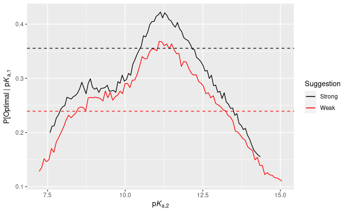

```r
# Plot the probabilities to determine how to describe the optimal range
ggplot() +
  geom_path(data = range.pka2.wk, mapping = aes(x = pka2, y = p.pka2, color = 'weak')) +
  geom_hline(yintercept = 0.5*diff(range(range.pka2.wk$p.pka2))+min(range.pka2.wk$p.pka2),
             color = 'red', linetype = 2) +
  geom_path(data = range.pka2.st, mapping = aes(x = pka2, y = p.pka2, color = 'strong')) +
  geom_hline(yintercept = 0.75*diff(range(range.pka2.st$p.pka2))+min(range.pka2.st$p.pka2),
             color = 'black', linetype = 2) +
  labs(x = expression('p'*italic(K)['a,2']), y = expression('P[Optimal | p'*italic(K)['a,1'])) +
  scale_color_manual(labels = c('weak' = 'Weak', 'strong' = 'Strong'),
                     name = 'Suggestion',
                     values = c('weak' = 'red', 'strong' = 'black'))

# Weak range: between 7~10 and above 12. However, the tailing effect of being above 12 is barely over the cutoff, so will be omitted for simplicity.
pka2.rng.wk = range(filter(range.pka2.wk, p.pka2 > 0.5*diff(range(p.pka2)) +min(p.pka2))$pka2)
pka2.rng.st = range(filter(range.pka2.st, p.pka2 > 0.75*diff(range(p.pka2))+min(p.pka2))$pka2)

print('First pKa:')
```

```
[1] "First pKa:"
```

```r
print('Weak range:')
```

```
[1] "Weak range:"
```

```r
print('Between:')
```

```
[1] "Between:"
```

```r
round(pka2.rng.wk, 2)
```

```
[1]  8.49 13.23
```

```r
print('Strong range:')
```

```
[1] "Strong range:"
```

```r
print('Between')
```

```
[1] "Between"
```

```r
round(pka2.rng.st, 2)
```

```
[1] 10.52 12.09
```

Range for the 2nd pKa: Weak suggestion: 8.49 ~ 13.23 Strong suggestion: 10.52 ~ 12.09

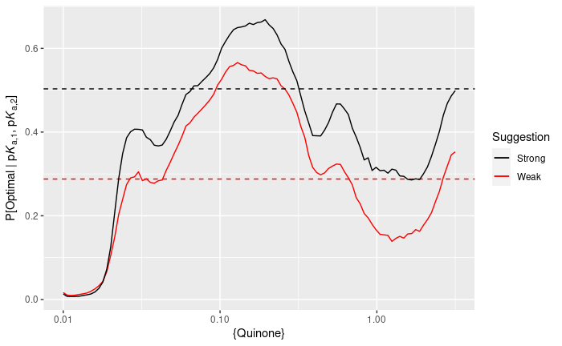

```r
ggplot() +
  geom_path(data = range.logA, mapping = aes(x = 10^logA, y = p.logA.wk, color = 'weak')) +
  geom_hline(yintercept = 0.5*diff(range(range.logA$p.logA.wk))+min(range.logA$p.logA.wk),
             color = 'red', linetype = 2) +
  geom_path(data = range.logA, mapping = aes(x = 10^logA, y = p.logA.st, color = 'strong')) +
  geom_hline(yintercept = 0.75*diff(range(range.logA$p.logA.st))+min(range.logA$p.logA.st),
             color = 'black', linetype = 2) +
  labs(x = '{Quinone}', y = expression('P[Optimal | p'*italic(K)['a,1']*', p'*italic(K)['a,2']*']')) +
  scale_color_manual(labels = c('weak' = 'Weak', 'strong' = 'Strong'),
                     name = 'Suggestion',
                     values = c('weak' = 'red', 'strong' = 'black')) +
  scale_x_log10()

# Ranges. The weak suggestion has a slight dip under, but it is nearly flat at that point, so I will include it in the range
logA.rng.wk = range(filter(range.logA, p.logA.wk > 0.5*diff(range(p.logA.wk)) +min(p.logA.wk))$logA)
logA.rng.st = range(filter(range.logA, p.logA.st > 0.75*diff(range(p.logA.st))+min(p.logA.st))$logA)

print('First pKa:')
```

```
[1] "First pKa:"
```

```r
print('Weak range:')
```

```
[1] "Weak range:"
```

```r
print('Between:')
```

```
[1] "Between:"
```

```r
round(10^logA.rng.wk, 2)
```

```
[1] 0.03 3.16
```

```r
print('Strong range:')
```

```
[1] "Strong range:"
```

```r
print('Between')
```

```
[1] "Between"
```

```r
round(10^logA.rng.st, 2)
```

```
[1] 0.07 0.31
```

Range for Quinone concentration Weak suggestion: 30 mM ~ 3.1 M Strong suggestion: 70 mM ~ 310 mM

[figure not shown]

Range for the 1st pKa: Weak suggestion: 7.23 ~ 9.55 Strong suggestion: 7.58 ~ 8.85

Range for the 2nd pKa: Weak suggestion: 8.49 ~ 13.23 Strong suggestion: 10.52 ~ 12.09

Range for Quinone concentration Weak suggestion: 30 mM ~ 3.1 M Strong suggestion: 70 mM ~ 310 mM

# Compare to known data

A small set of quinone pKas was used to constrain the search space. This same dataset can be assessed for the likelihood that any compound will be viable given only the pKa values.

[output not shown]

```r
quinone.data[order(quinone.data$p.accept, decreasing = TRUE), !(names(quinone.data) %in% c('QuinoneCode', 'E0.1', 'E0.2'))]
```

Based solely on pKa information available, 5 quinones have a moderate likelihood of having low energy demands (probability of acceptance about > 40%). These 5 candidates have pKa values that are within the strong suggestion spans:

- pKa1: 7.77 ~ 8.19 compared to the calculated 7.58 ~ 8.85
- pKa2: 10.61 ~ 11.32 compared to the calculated 10.52 ~ 12.09

The top candidates appear to have a strongly electron withdrawing oxygen at the second carbon, and 4 of the top 5 have additional oxygen-containing groups on other carbons. This is promising given that these groups are likely to increase the solubility limit enough to fall within the optimal region, although it may lead to greater sensitivity to oxygen gas due to an increase in the electrophilicity of the carbons.